# Compute-Aware Mixture-of-Experts for 5G Neural Receivers

## Progress Defense — 2026-04-30

**Team:** Dominik Huml (xhumld00), Jakub Kontrík (xkontr02), Martin Vaculík (xvaculm00)

**Repository:** https://github.com/TheRamsay/moe-5g-nrx

## In one sentence

We built a 5G neural receiver where a small router examines channel quality features and dispatches each received OFDM slot to one of three different-sized experts — matching the dense baseline's BLER while using **only 56% of the FLOPs**, with the routing learned from a FLOPs penalty in the loss (no SNR labels).

## What's new since the checkpoint report

The checkpoint report ended at: **asymmetric warm-start, 0.910 BLER, 61% FLOPs, single seed.** Since then we have run roughly ten new experiments. Here is the complete summary; each is detailed below.

| # | Experiment | Status | Key finding |
| --- | --- | --- | --- |
| 1 | **Alpha sweep** (4 values) | ✅ | exp26 (α=2e-3) is the Pareto knee: **0.902 BLER / 56% FLOPs** |
| 2 | **3-seed confirmation** | ✅ | Bimodal: 2/3 reproduce (s67, s42), **1/3 collapses** (s32 → 0.958) |
| 3 | **Stabilization** ×2 | ⚠️ | large-warmup → 100% large; β-warmup → worse BLER. Both failed. |
| 4 | **Random-router ablation** | ✅ | Replace router input with noise → **BLER craters 6.6 pp** |
| 5 | **2-expert ablation** | ✅ | Dropping nano costs **0.7 pp BLER + 9 pp FLOPs** |
| 6 | **DeepMIMO OOD eval** | ⚠️ | All models fail (~0.99 BLER) on ray-traced data |
| 7 | **Few-shot fine-tune** | ⚠️ | 500 steps / 2k samples insufficient. Honest scope. |
| 8 | **SNR-oracle baseline** | ✅ | Hand-rule with true SNR: 0.900 / 49%. exp26 on Pareto without oracle. |
| 9 | **Explicit SNR-input ablation** (exp38, today) | ✅ | Adding SNR proxies → **collapse to 100% large** |

Legend: ✅ = positive result that informs design; ⚠️ = honest negative result.

```python
import matplotlib.pyplot as plt
import numpy as np
import pandas as pd
from IPython.display import Image, Markdown, display
from pathlib import Path

FIGURES = Path('figures')

# Visual style
plt.rcParams.update({
    'figure.figsize': (10, 5.5),
    'axes.grid': True,
    'grid.alpha': 0.25,
    'axes.spines.top': False,
    'axes.spines.right': False,
    'font.size': 11,
    'axes.titlesize': 13,
    'axes.titleweight': 'bold',
    'axes.labelsize': 11,
    'legend.frameon': False,
})

# Consistent color palette
C = {
    'large': '#1f4e79',  # deep blue
    'small': '#5b9bd5',  # mid blue
    'nano': '#a8d4f0',   # light blue
    'exp26': '#c0504d',  # red — our winner
    'oracle': '#9d9d9d', # grey — reference
    'fail': '#cf6f6f',   # muted red — negative result
    'ok': '#4a7c59',     # green — positive result
}

def fig_exists(name):
    return (FIGURES / name).exists()

print('Setup complete.')
```

```
Setup complete.
```

## 1. The problem

A 5G neural receiver decodes OFDM symbols into bits. The **dense baseline** (Wiesmayr et al. 2024) applies the same compute to every slot regardless of how easy or hard it is.

Static dense receivers waste compute on the easy ones. We want **compute that scales with channel difficulty.**

**Why it matters:** mobile devices have limited battery and thermal budgets. Adaptive compute saves energy.

## 2. Architecture

Three components in series:

1. **Shared stem** (285M FLOPs, always paid) — processes received signal + LS channel estimate, produces features
2. **Channel-aware router** (tiny MLP) — pools stem features (mean+max over freq, time), outputs probability over 3 experts
3. **Three heterogeneous experts** — different compute capacities, only ONE runs at inference (hard top-1)

**Loss:** $L = L_{BCE} + \gamma \cdot L_{channel\_MSE} + \alpha \cdot \mathbb{E}[\text{FLOPs ratio}] + \beta \cdot L_{balance}$

- $\gamma = 0.05$ (channel estimation regularizer — domain-specific)
- $\alpha$ controls FLOPs/quality tradeoff (we sweep this)
- $\beta = 0.1$ prevents collapse to a single expert

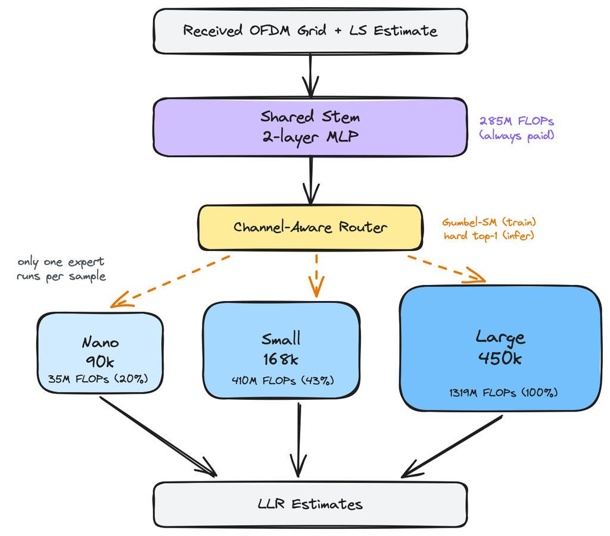

```python
# Show architecture if available
if fig_exists('archictures.png'):
    display(Image(filename=str(FIGURES / 'archictures.png'), width=900))
else:
    print('Architecture figure not found locally.')
```

```python
# Expert sizes — derived from pre-trained dense baselines
experts = pd.DataFrame({
    'Expert': ['nano', 'small', 'large'],
    'Block dim': [8, 32, 64],
    'Blocks': [4, 8, 8],
    'Params (k)': [90, 168, 450],
    'Total FLOPs (M)': [320, 695, 1604],
    '% of large': ['20%', '43%', '100%'],
})
experts.style.set_caption('Heterogeneous experts (sized to match pre-trained dense baselines)')
```

Heterogeneous experts (sized to match pre-trained dense baselines)

|  | Expert | Block dim | Blocks | Params (k) | Total FLOPs (M) | % of large |
| --- | --- | --- | --- | --- | --- | --- |
| 0 | nano | 8 | 4 | 90 | 320 | 20% |
| 1 | small | 32 | 8 | 168 | 695 | 43% |
| 2 | large | 64 | 8 | 450 | 1604 | 100% |

## 3. The training journey — three phases, two failure modes, one fix

We hit **two opposite failure modes** before finding what works.

### Phase 1 — joint training from scratch (cold start)

All experts random init. The FLOPs penalty kicks in early when none of them are good. Router learns: *"large is expensive, abandon it."*

→ **BLER 0.926 / 48% FLOPs** — cheap but BLER bleeds.

### Phase 2 — full warm-start

Each expert initialized from its pre-trained dense checkpoint. Router sees: *"warm-large is strictly better than warm-nano/small from step 1."* Locks onto large, never explores.

→ **BLER 0.879 / 100% FLOPs** — basically a fine-tuned dense large.

### Anti-collapse experiments (5 attempts, all failed)

Stronger β, β=2.0 forced uniform, capacity constraints, Switch-Transformer auxiliary loss — all either collapse or kill BLER.

### Phase 3 — asymmetric warm-start (the breakthrough)

→ **All three experts active by step 10–12k.** This is the recipe everything else is built on.

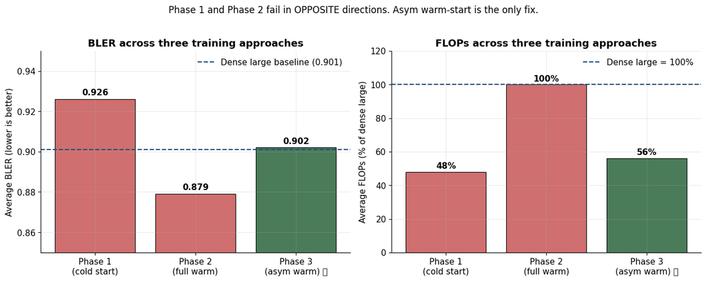

```python
# Visualize the three phases
phases = pd.DataFrame({
    'Phase': ['Phase 1\n(cold start)', 'Phase 2\n(full warm)', 'Phase 3\n(asym warm) ⭐'],
    'BLER': [0.926, 0.879, 0.902],
    'FLOPs %': [48, 100, 56],
})

fig, (ax1, ax2) = plt.subplots(1, 2, figsize=(13, 5))

colors = [C['fail'], C['fail'], C['ok']]
ax1.bar(phases['Phase'], phases['BLER'], color=colors, edgecolor='black', linewidth=0.8)
ax1.axhline(y=0.901, color=C['large'], linestyle='--', linewidth=1.5, label='Dense large baseline (0.901)')
ax1.set_ylabel('Average BLER (lower is better)')
ax1.set_title('BLER across three training approaches')
ax1.set_ylim(0.85, 0.95)
ax1.legend(loc='upper right')
for i, v in enumerate(phases['BLER']):
    ax1.text(i, v + 0.002, f'{v:.3f}', ha='center', fontweight='bold')

ax2.bar(phases['Phase'], phases['FLOPs %'], color=colors, edgecolor='black', linewidth=0.8)
ax2.axhline(y=100, color=C['large'], linestyle='--', linewidth=1.5, label='Dense large = 100%')
ax2.set_ylabel('Average FLOPs (% of dense large)')
ax2.set_title('FLOPs across three training approaches')
ax2.set_ylim(0, 120)
ax2.legend(loc='upper right')
for i, v in enumerate(phases['FLOPs %']):
    ax2.text(i, v + 2, f'{v}%', ha='center', fontweight='bold')

plt.suptitle('Phase 1 and Phase 2 fail in OPPOSITE directions. Asym warm-start is the only fix.',
             fontsize=12, y=1.02)
plt.tight_layout()
plt.show()
```

```
Expert usage during asymmetric warm-start training:
```

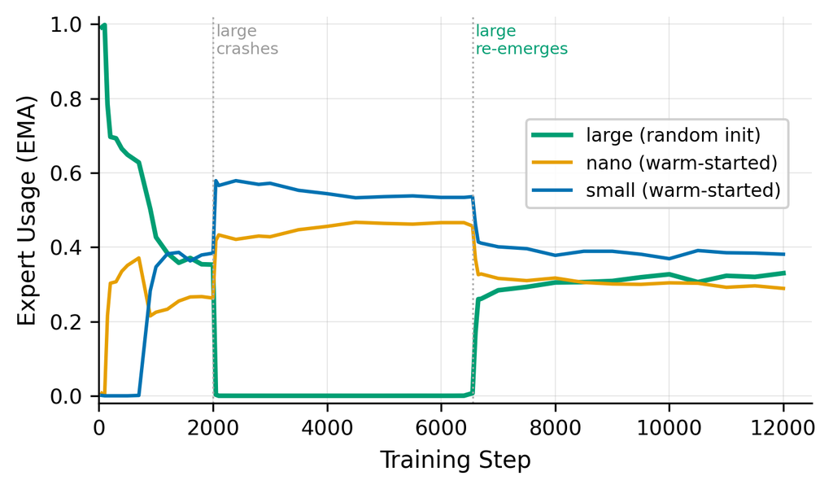

```
Large (random init) crashes to ~0% by step 2000, then begins receiving traffic at step ~6500
and reaches competitive usage by step ~8000-10000. The router *discovers* large once it earns its spot.
```

```python
# Show training dynamics of the asym warm-start (when large 'wakes up')
if fig_exists('expert_usage_asym_warm.png'):
    print('Expert usage during asymmetric warm-start training:')
    display(Image(filename=str(FIGURES / 'expert_usage_asym_warm.png'), width=850))
    print('\nLarge (random init) crashes to ~0% by step 2000, then begins receiving traffic at step ~6500')
    print('and reaches competitive usage by step ~8000-10000. The router *discovers* large once it earns its spot.')
```

## 4. The headline result — alpha sweep finds the Pareto knee

After asymmetric warm-start worked, we ran a **4-point sweep over the FLOPs penalty α** to find the best operating point on the BLER vs FLOPs Pareto curve.

```python
# Alpha sweep results (test split, 50k subset)
sweep = pd.DataFrame({
    'Run': ['Dense large', 'exp24', 'exp25', 'exp26 ⭐', 'exp27'],
    'α': ['—', '5e-4', '1e-3', '2e-3', '5e-3'],
    'Avg BLER': [0.901, 0.898, 0.907, 0.902, 0.911],
    'FLOPs %': [100, 100, 56, 56, 60],
    'Routing l/n/s': ['—', '100/0/0', '44/12/44', '44/15/40', '37/0/63'],
    'Verdict': ['reference', 'α too weak → collapse to large', 'dominated by exp26',
                'KNEE OF PARETO', 'α too strong → nano starved'],
})

def style_sweep(s):
    color = ['background-color: #fff4d6' if r == 'exp26 ⭐' else '' for r in s]
    return color

sweep.style.apply(style_sweep, subset=['Run']).set_caption('Alpha sweep: exp26 dominates the rest')
```

Alpha sweep: exp26 dominates the rest

|  | Run | α | Avg BLER | FLOPs % | Routing l/n/s | Verdict |
| --- | --- | --- | --- | --- | --- | --- |
| 0 | Dense large | — | 0.901000 | 100 | — | reference |
| 1 | exp24 | 5e-4 | 0.898000 | 100 | 100/0/0 | α too weak → collapse to large |
| 2 | exp25 | 1e-3 | 0.907000 | 56 | 44/12/44 | dominated by exp26 |
| 3 | exp26 ⭐ | 2e-3 | 0.902000 | 56 | 44/15/40 | KNEE OF PARETO |
| 4 | exp27 | 5e-3 | 0.911000 | 60 | 37/0/63 | α too strong → nano starved |

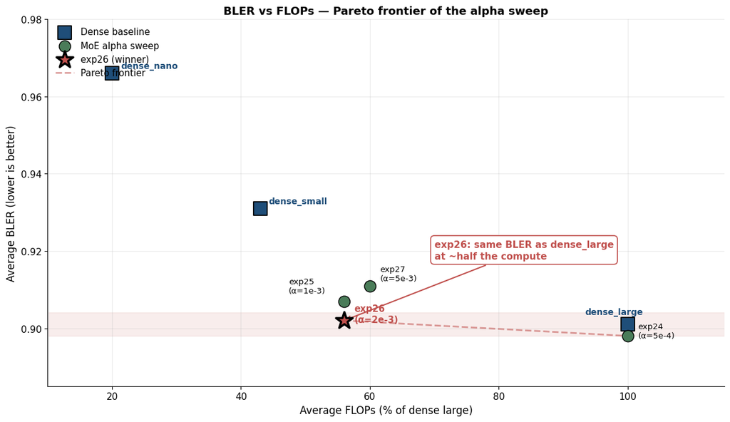

```
Key result: exp26 (α=2e-3) matches dense_large quality (0.902 vs 0.901 BLER)
using only 56% FLOPs. Strict Pareto improvement over the asym-warm anchor (0.910 / 61%).
```

```python
# Pareto plot — clean layout with no label collisions
fig, ax = plt.subplots(figsize=(12, 7))

# Dense baselines (square markers, blue)
dense = [
    {'name': 'dense_nano',  'BLER': 0.966, 'FLOPs': 20,  'offset': (10, 6)},
    {'name': 'dense_small', 'BLER': 0.931, 'FLOPs': 43,  'offset': (10, 6)},
    {'name': 'dense_large', 'BLER': 0.901, 'FLOPs': 100, 'offset': (-50, 12)},
]
for d in dense:
    ax.scatter(d['FLOPs'], d['BLER'], s=240, marker='s', color=C['large'],
               edgecolor='black', linewidth=1.3, zorder=5,
               label='Dense baseline' if d['name'] == 'dense_nano' else None)
    ax.annotate(d['name'], (d['FLOPs'], d['BLER']),
                textcoords='offset points', xytext=d['offset'],
                fontsize=10, color=C['large'], fontweight='bold')

# MoE alpha sweep (circles)
moe = [
    {'name': 'exp24',  'alpha': 'α=5e-4', 'BLER': 0.898, 'FLOPs': 100, 'offset': (12, -2),  'highlight': False},
    {'name': 'exp25',  'alpha': 'α=1e-3', 'BLER': 0.907, 'FLOPs': 56,  'offset': (-65, 10), 'highlight': False},
    {'name': 'exp26',  'alpha': 'α=2e-3', 'BLER': 0.902, 'FLOPs': 56,  'offset': (12, -2),  'highlight': True},
    {'name': 'exp27',  'alpha': 'α=5e-3', 'BLER': 0.911, 'FLOPs': 60,  'offset': (12, 6),   'highlight': False},
]
labelled = False
for m in moe:
    if m['highlight']:
        ax.scatter(m['FLOPs'], m['BLER'], s=420, color=C['exp26'],
                   edgecolor='black', linewidth=2.5, zorder=7,
                   marker='*', label='exp26 (winner)')
    else:
        kw = {'label': 'MoE alpha sweep'} if not labelled else {}
        ax.scatter(m['FLOPs'], m['BLER'], s=180, color='#4a7c59',
                   edgecolor='black', linewidth=1.0, zorder=6, **kw)
        labelled = True
    label_text = f"{m['name']}\n({m['alpha']})"
    fw = 'bold' if m['highlight'] else 'normal'
    fs = 10.5 if m['highlight'] else 9.5
    color = C['exp26'] if m['highlight'] else 'black'
    ax.annotate(label_text, (m['FLOPs'], m['BLER']),
                textcoords='offset points', xytext=m['offset'],
                fontsize=fs, fontweight=fw, color=color, ha='left')

# Pareto frontier line — between exp26 (best at 56%) and exp24/dense_large (best at 100%)
pareto_x = [56, 100]
pareto_y = [0.902, 0.898]
ax.plot(pareto_x, pareto_y, '--', color=C['exp26'], alpha=0.55, linewidth=2.0,
        label='Pareto frontier', zorder=2)

# Highlight the "matches dense" zone
ax.axhspan(0.898, 0.904, alpha=0.10, color=C['exp26'], zorder=1)

# Annotate the key insight
ax.annotate('exp26: same BLER as dense_large\nat ~half the compute',
            xy=(56, 0.902), xytext=(70, 0.918),
            fontsize=11, color=C['exp26'], fontweight='bold',
            arrowprops=dict(arrowstyle='->', color=C['exp26'], lw=1.5),
            bbox=dict(boxstyle='round,pad=0.4', facecolor='white',
                      edgecolor=C['exp26'], linewidth=1.2))

ax.set_xlabel('Average FLOPs (% of dense large)', fontsize=12)
ax.set_ylabel('Average BLER (lower is better)', fontsize=12)
ax.set_title('BLER vs FLOPs — Pareto frontier of the alpha sweep',
             fontsize=13, fontweight='bold')
ax.set_xlim(10, 115)
ax.set_ylim(0.885, 0.98)
ax.legend(loc='upper left', fontsize=10.5, framealpha=0.95)

plt.tight_layout()
plt.show()

print('\nKey result: exp26 (α=2e-3) matches dense_large quality (0.902 vs 0.901 BLER)')
print('using only 56% FLOPs. Strict Pareto improvement over the asym-warm anchor (0.910 / 61%).')
```

## 5. Ablations — proving the design choices are load-bearing

These are the questions a sharp reviewer would ask. We answered all three.

### 5.1 Is the router actually using channel features, or could it be random?

We replaced the router input with `torch.randn` — same training recipe, same losses, same architecture, but the router can no longer see channel quality.

**Result: BLER craters by 6.6 pp AND the router collapses to small (large is never used).**

This is the **central claim of the project**: channel-aware features matter causally.

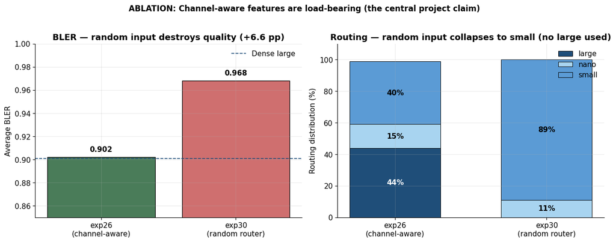

```python
# Random router ablation
fig, (ax1, ax2) = plt.subplots(1, 2, figsize=(13, 5))

labels = ['exp26\n(channel-aware)', 'exp30\n(random router)']
bler = [0.902, 0.968]
colors_a = [C['ok'], C['fail']]

bars = ax1.bar(labels, bler, color=colors_a, edgecolor='black', linewidth=0.9)
ax1.axhline(y=0.901, color=C['large'], linestyle='--', linewidth=1.2, label='Dense large')
ax1.set_ylabel('Average BLER')
ax1.set_title('BLER — random input destroys quality (+6.6 pp)')
ax1.set_ylim(0.85, 1.0)
for i, v in enumerate(bler):
    ax1.text(i, v + 0.005, f'{v:.3f}', ha='center', fontweight='bold')
ax1.legend()

# Routing distribution
routing_data = {
    'large': [44, 0],
    'nano': [15, 11],
    'small': [40, 89],
}
x = np.arange(2)
width = 0.6
bottoms = np.zeros(2)
for expert, vals in routing_data.items():
    ax2.bar(x, vals, width, bottom=bottoms, label=expert,
            color=C[expert], edgecolor='black', linewidth=0.7)
    for i, v in enumerate(vals):
        if v > 5:
            ax2.text(x[i], bottoms[i] + v / 2, f'{v}%', ha='center', va='center',
                     color='white' if expert == 'large' else 'black', fontweight='bold')
    bottoms += np.array(vals)

ax2.set_xticks(x)
ax2.set_xticklabels(labels)
ax2.set_ylabel('Routing distribution (%)')
ax2.set_title('Routing — random input collapses to small (no large used)')
ax2.legend(loc='upper right')
ax2.set_ylim(0, 110)

plt.suptitle('ABLATION: Channel-aware features are load-bearing (the central project claim)',
             fontsize=12, y=1.02, fontweight='bold')
plt.tight_layout()
plt.show()
```

### 5.2 Do you really need three experts, or would two suffice?

We dropped nano and trained with only {small, large}.

**Result: 0.7 pp worse BLER + 9 pp more FLOPs.**

Nano is non-decorative — it absorbs hopeless low-SNR samples that small would burn compute on. Without nano, small picks up that traffic instead of large.

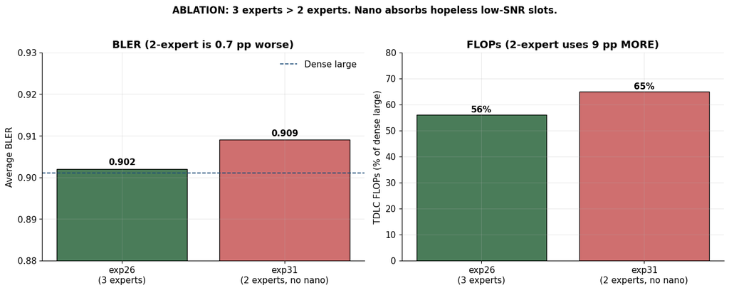

```python
# 2-expert ablation
fig, (ax1, ax2) = plt.subplots(1, 2, figsize=(13, 5))

labels = ['exp26\n(3 experts)', 'exp31\n(2 experts, no nano)']
bler = [0.902, 0.909]
flops = [56, 65]

ax1.bar(labels, bler, color=[C['ok'], C['fail']], edgecolor='black', linewidth=0.9)
ax1.axhline(y=0.901, color=C['large'], linestyle='--', linewidth=1.2, label='Dense large')
ax1.set_ylabel('Average BLER')
ax1.set_title('BLER (2-expert is 0.7 pp worse)')
ax1.set_ylim(0.88, 0.93)
for i, v in enumerate(bler):
    ax1.text(i, v + 0.001, f'{v:.3f}', ha='center', fontweight='bold')
ax1.legend()

ax2.bar(labels, flops, color=[C['ok'], C['fail']], edgecolor='black', linewidth=0.9)
ax2.set_ylabel('TDLC FLOPs (% of dense large)')
ax2.set_title('FLOPs (2-expert uses 9 pp MORE)')
ax2.set_ylim(0, 80)
for i, v in enumerate(flops):
    ax2.text(i, v + 1, f'{v}%', ha='center', fontweight='bold')

plt.suptitle('ABLATION: 3 experts > 2 experts. Nano absorbs hopeless low-SNR slots.',
             fontsize=12, y=1.02, fontweight='bold')
plt.tight_layout()
plt.show()
```

### 5.3 Does explicit SNR knowledge help? (exp38, today)

The router currently uses pooled stem features — *implicit* channel quality. We hypothesized that adding **explicit domain statistics** (received power, channel power, channel variance — all SNR proxies computable at inference) might help.

**Result: complete collapse to 100% large.**

This is actually a clean finding: the implicit stem features already encode what those statistics capture. Explicitly handing the router an SNR proxy made it too easy to identify *"large is always best"* and lock in.

**Interpretation:** the channel-aware routing is already leveraging domain knowledge — just learned, not hand-engineered.

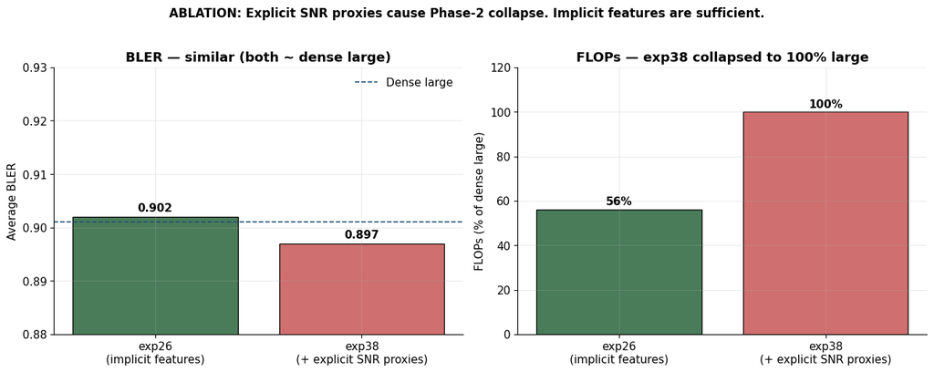

```python
# exp38 SNR-input ablation
fig, (ax1, ax2) = plt.subplots(1, 2, figsize=(13, 5))

labels = ['exp26\n(implicit features)', 'exp38\n(+ explicit SNR proxies)']
bler = [0.902, 0.897]
flops = [56, 100]

ax1.bar(labels, bler, color=[C['ok'], C['fail']], edgecolor='black', linewidth=0.9)
ax1.axhline(y=0.901, color=C['large'], linestyle='--', linewidth=1.2, label='Dense large')
ax1.set_ylabel('Average BLER')
ax1.set_title('BLER — similar (both ~ dense large)')
ax1.set_ylim(0.88, 0.93)
for i, v in enumerate(bler):
    ax1.text(i, v + 0.001, f'{v:.3f}', ha='center', fontweight='bold')
ax1.legend()

ax2.bar(labels, flops, color=[C['ok'], C['fail']], edgecolor='black', linewidth=0.9)
ax2.set_ylabel('FLOPs (% of dense large)')
ax2.set_title('FLOPs — exp38 collapsed to 100% large')
ax2.set_ylim(0, 120)
for i, v in enumerate(flops):
    ax2.text(i, v + 2, f'{v}%', ha='center', fontweight='bold')

plt.suptitle('ABLATION: Explicit SNR proxies cause Phase-2 collapse. Implicit features are sufficient.',
             fontsize=12, y=1.02, fontweight='bold')
plt.tight_layout()
plt.show()
```

## 6. Honest weaknesses — what we own

### 6.1 Seed stability — bimodal

We re-ran α=2e-3 with two additional seeds (32 and 42) alongside our headline seed 67.

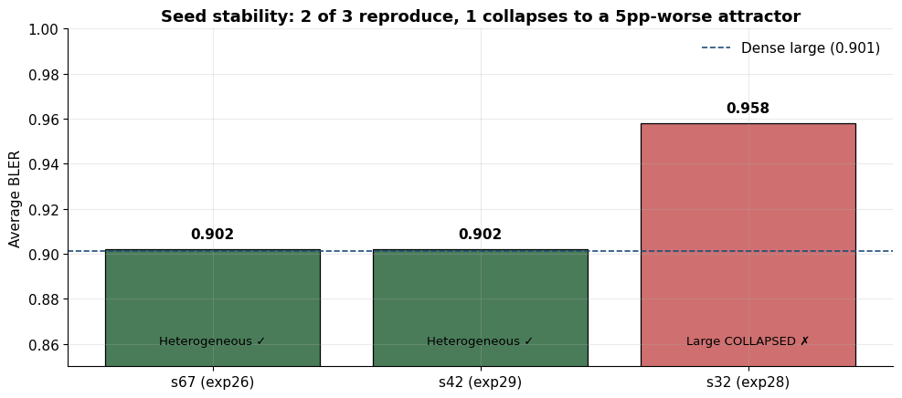

|  | Seed | BLER | Routing l/n/s | Outcome |
| --- | --- | --- | --- | --- |
| 0 | s67 (exp26) | 0.902 | 44/15/40 | Heterogeneous ✓ |
| 1 | s42 (exp29) | 0.902 | 55/12/33 | Heterogeneous ✓ |
| 2 | s32 (exp28) | 0.958 | 0/49/51 | Large COLLAPSED ✗ |

```
Both stabilization recipes we tried — large-warmup and β-warmup — FAILED:
  • large-warmup (freeze nano+small for 2k steps): 3/3 seeds → 100% large (over-corrects)
  • β-warmup (β=0.5 for 4k steps, drop to 0.1):    mean BLER 0.938 ± 0.024 (worse than baseline)

We report the bimodal distribution honestly. Recipe stability is an open problem.
```

```python
# 3-seed bimodal result
seeds = pd.DataFrame({
    'Seed': ['s67 (exp26)', 's42 (exp29)', 's32 (exp28)'],
    'BLER': [0.902, 0.902, 0.958],
    'Routing l/n/s': ['44/15/40', '55/12/33', '0/49/51'],
    'Outcome': ['Heterogeneous ✓', 'Heterogeneous ✓', 'Large COLLAPSED ✗'],
})

fig, ax = plt.subplots(figsize=(10, 4.5))
colors_s = [C['ok'], C['ok'], C['fail']]
ax.bar(seeds['Seed'], seeds['BLER'], color=colors_s, edgecolor='black', linewidth=0.9)
ax.axhline(y=0.901, color=C['large'], linestyle='--', linewidth=1.2, label='Dense large (0.901)')
ax.set_ylabel('Average BLER')
ax.set_title('Seed stability: 2 of 3 reproduce, 1 collapses to a 5pp-worse attractor')
ax.set_ylim(0.85, 1.0)
for i, (v, o) in enumerate(zip(seeds['BLER'], seeds['Outcome'])):
    ax.text(i, v + 0.005, f'{v:.3f}', ha='center', fontweight='bold')
    ax.text(i, 0.86, o, ha='center', fontsize=9.5)
ax.legend()
plt.tight_layout()
plt.show()

display(seeds)

print("\nBoth stabilization recipes we tried — large-warmup and β-warmup — FAILED:")
print("  • large-warmup (freeze nano+small for 2k steps): 3/3 seeds → 100% large (over-corrects)")
print("  • β-warmup (β=0.5 for 4k steps, drop to 0.1):    mean BLER 0.938 ± 0.024 (worse than baseline)")
print("\nWe report the bimodal distribution honestly. Recipe stability is an open problem.")
```

### 6.2 OOD generalization — synthetic-only scope

We tested on **DeepMIMO ray-traced data** (ASU campus, 3.5 GHz) — real propagation, not 3GPP stochastic models.

**All three of our models — including dense large — fail catastrophically (~0.99 BLER).**

We then tried a **few-shot fine-tune** (500 steps, 2k OOD samples).

```python
ood = pd.DataFrame({
    'Model': ['dense_large', 'exp26 (3-expert)', 'exp31 (2-expert)'],
    'TDLC BLER (in-dist)': [0.866, 0.867, 0.878],
    'OOD BLER (zero-shot)': [0.990, 0.992, 0.993],
    'OOD BLER (post-FT)': [0.9901, 0.9915, '—'],
    'OOD FLOPs %': [100, 32, 71],
})

display(ood.style.set_caption('DeepMIMO OOD evaluation — all models fail; brief fine-tune insufficient'))

print("\nKey findings:")
print("  ✗ Synthetic-trained NRX cannot decode ray-traced channels without OOD adaptation.")
print("  ✗ 500 steps / 2k samples is INSUFFICIENT to bridge the synthetic-vs-ray-traced gap.")
print("  ✓ NO catastrophic forgetting on in-distribution data.")
print("  ✓ Routing did NOT adapt to OOD (nano-default behavior preserved).")
print("  ⚪ Bonus: 3-expert MoE *uses less compute* on OOD (router defaults to nano under unfamiliar features).")
print("\nHonest scope statement: this work is for synthetic 3GPP channels.")
print("Bridging to ray-traced needs more data and training time than we had — out of scope.")
```

DeepMIMO OOD evaluation — all models fail; brief fine-tune insufficient

|  | Model | TDLC BLER (in-dist) | OOD BLER (zero-shot) | OOD BLER (post-FT) | OOD FLOPs % |
| --- | --- | --- | --- | --- | --- |
| 0 | dense_large | 0.866000 | 0.990000 | 0.990100 | 100 |
| 1 | exp26 (3-expert) | 0.867000 | 0.992000 | 0.991500 | 32 |
| 2 | exp31 (2-expert) | 0.878000 | 0.993000 | — | 71 |

```
Key findings:
  ✗ Synthetic-trained NRX cannot decode ray-traced channels without OOD adaptation.
  ✗ 500 steps / 2k samples is INSUFFICIENT to bridge the synthetic-vs-ray-traced gap.
  ✓ NO catastrophic forgetting on in-distribution data.
  ✓ Routing did NOT adapt to OOD (nano-default behavior preserved).
  ⚪ Bonus: 3-expert MoE *uses less compute* on OOD (router defaults to nano under unfamiliar features).

Honest scope statement: this work is for synthetic 3GPP channels.
Bridging to ray-traced needs more data and training time than we had — out of scope.
```

### 6.3 SNR-oracle baseline — theoretical upper bound

We built a hand-rule cascade (NOT a trained model) that uses **true SNR** to pick the cheapest expert that clears a BLER tolerance. This shows the theoretical ceiling of what's achievable with these three experts.

```python
oracle = pd.DataFrame({
    'Strategy': ['Per-profile static (best fixed rule)',
                 'SNR-oracle cascade tol+0.01..0.02',
                 'exp26 LEARNED MoE',
                 'SNR-oracle cascade tol+0.05',
                 'SNR-oracle cascade tol+0.10'],
    'Avg BLER': [0.900, 0.900, 0.902, 0.909, 0.919],
    'FLOPs %': [100, 49, 56, 35, 27],
    'Notes': ['both -> large always', 'oracle SNR access (NOT deployable)',
              'NO oracle access', 'aggressive: relax BLER', 'very aggressive']
})

def style_oracle(s):
    return ['background-color: #fff4d6' if 'exp26' in r else '' for r in s]

display(oracle.style.apply(style_oracle, subset=['Strategy'])
        .set_caption('SNR-oracle cascade -- theoretical baseline (true SNR not available at inference)'))

print()
print('Honest finding:')
print('  - exp26 (NO oracle access): 0.902 BLER at 56% FLOPs')
print('  - Oracle (with TRUE SNR):   0.900 BLER at 49% FLOPs')
print('  -> 7 pp FLOPs gap between learned routing and theoretical optimum.')
print()
print('Did we try closing the gap by feeding raw SNR proxies to the router?')
print('YES -- exp38 (next section). Result: 100% collapse to large.')
print('Implicit stem features outperformed explicit raw signal statistics.')
print()
print('A properly trained SNR-estimator MODULE (not raw stats) might behave')
print('differently -- that is the genuinely open future direction.')
```

SNR-oracle cascade -- theoretical baseline (true SNR not available at inference)

|  | Strategy | Avg BLER | FLOPs % | Notes |
| --- | --- | --- | --- | --- |
| 0 | Per-profile static (best fixed rule) | 0.900000 | 100 | both -> large always |
| 1 | SNR-oracle cascade tol+0.01..0.02 | 0.900000 | 49 | oracle SNR access (NOT deployable) |
| 2 | exp26 LEARNED MoE | 0.902000 | 56 | NO oracle access |
| 3 | SNR-oracle cascade tol+0.05 | 0.909000 | 35 | aggressive: relax BLER |
| 4 | SNR-oracle cascade tol+0.10 | 0.919000 | 27 | very aggressive |

[output not shown]

## 7. Per-SNR routing — the router learned a difficulty-dependent policy

Decomposing expert usage by SNR bin reveals the router has learned a **difficulty-dependent routing policy** within each channel profile, not just per-profile preferences.

```
Expert routing by SNR bin (test split):
```

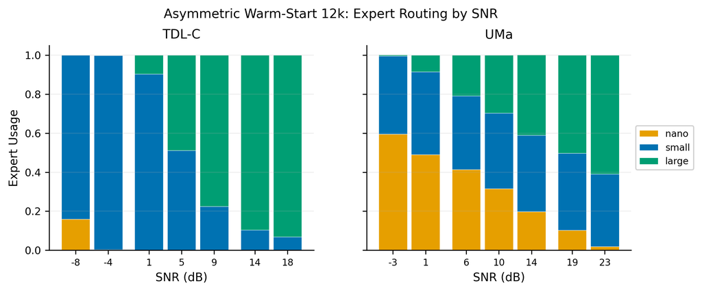

```
BLER comparison across SNR bins:
```

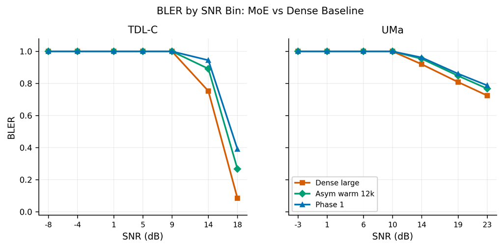

```
TDLC waterfall region — dense baselines:
```

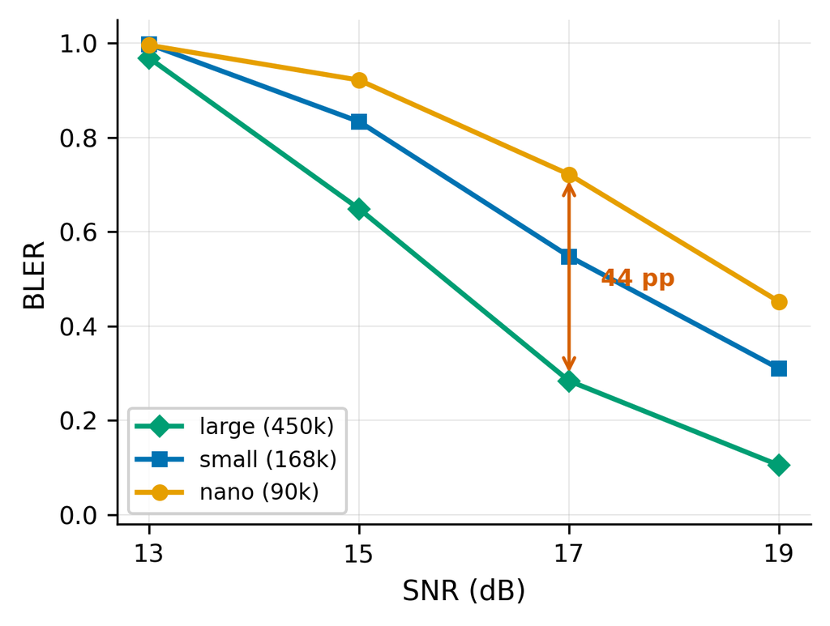

```python
# Show per-SNR routing if available
for figname, caption in [
    ('expert_usage_by_snr.png', 'Expert routing by SNR bin (test split)'),
    ('bler_by_snr_comparison.png', 'BLER comparison across SNR bins'),
    ('waterfall_dense_baselines.png', 'TDLC waterfall region — dense baselines'),
]:
    if fig_exists(figname):
        print(f'\n{caption}:')
        display(Image(filename=str(FIGURES / figname), width=850))
```

Interpretation of the per-SNR routing:

The router does NOT follow a naive *"hard → large, easy → nano"* policy. It learned to save compute when no expert can succeed, and only spend it when capacity matters.

## 8. What we did vs. prior work

| Work | What they did | What we add |
| --- | --- | --- |
| **Wiesmayr et al. 2024** | Defines dense NRX architecture | We use it as the baseline |
| **MEAN (van Bolderik 2024)** | MoE for 5G NRX, **homogeneous experts**, per-SNR specialisation, CDL-C only | We use **heterogeneous** experts (different compute), FLOPs penalty, mixed UMa+TDLC, full Pareto analysis. Orthogonal contribution: they target robustness, we target compute efficiency. |
| **Song et al. 2025** | Channel-aware gating in wireless | We instantiate this on top of an NRX with an explicit FLOPs penalty in the loss |

**Three things MEAN doesn't have:**

1. Heterogeneous expert sizes — actual compute heterogeneity, not just specialisation
2. FLOPs penalty in the loss — emergent compute-aware routing
3. Pareto analysis + ablations + oracle baseline — complete characterisation

## 9. Conclusions — what's real, what isn't

### Honest limitations ⚠️

- **Seed stability is bimodal:** 2/3 seeds reproduce, 1 collapses. Two stabilization recipes both failed.
- **OOD on ray-traced data fails** — synthetic-only scope. Brief fine-tune insufficient.
- **Slight gap to oracle:** with true SNR a hand-rule cascade reaches 49% FLOPs; we reach 56%. We tried closing it with raw signal stats (exp38) — that collapsed.

### Future work — three concrete experiments before the final deadline

1. **Proper inference latency benchmark with efficient dispatch.** Implement production-grade sparse-MoE dispatch (cf. Mixtral, vLLM kernels) and re-benchmark exp26 vs dense_large at multiple batch sizes. Current naive sequential dispatch doesn't translate FLOPs savings into wall-clock — we need to verify whether efficient dispatch fixes this.
2. **High-resolution per-SNR evaluation.** Current 7 bins per profile leaves only 2 points in the TDLC waterfall (14 dB, 18 dB). Resample at 1-2 dB steps across 10-20 dB to precisely characterise where exp26 diverges from dense_large.
3. **Router interpretability — what does the router *see*?** PCA/UMAP of stem features coloured by selected expert and by true SNR; saliency maps over the input grid; per-expert feature activation analysis. Preliminary PCA exists on the cluster — needs to be deepened.

Beyond these three, longer-horizon open problems: seed-stable training recipe; domain-randomized pretraining for OOD.

## 10. One number per claim (for quick reference)

| Claim | Evidence |
| --- | --- |
| Compute-aware MoE works | exp26: 0.902 BLER at 56% FLOPs (vs dense_large 0.901 at 100%) |
| Router uses channel features | random-router ablation: BLER craters 6.6 pp |
| 3 experts > 2 experts | drop-nano: 0.7 pp BLER + 9 pp FLOPs cost |
| Asym warm-start is the only recipe | Phase 1 and Phase 2 both fail; 5 anti-collapse mechanisms also failed |
| Implicit features are sufficient | exp38 (explicit SNR) collapses to 100% large |
| Seed stability | 2/3 seeds reproduce, 1 collapses; bimodal distribution |
| OOD generalization | synthetic-only scope; few-shot fine-tune insufficient |
| Oracle gap | hand-rule with true SNR reaches 49% FLOPs vs our 56% |

**Status:** experiments essentially complete (~10 distinct experiments, all with results). Remaining work: LaTeX rewrite of checkpoint report, poster (deadline 13 days).